# 2022-05-10 NYT Best Sellers

2022-05-11

# TidyTuesday

Join the R4DS Online Learning Community in the weekly #TidyTuesday event! Every week we post a raw dataset, a chart or article related to that dataset, and ask you to explore the data. While the dataset will be “tamed”, it will not always be tidy! As such you might need to apply various R for Data Science techniques to wrangle the data into a true tidy format. The goal of TidyTuesday is to apply your R skills, get feedback, explore other’s work, and connect with the greater #RStats community! As such we encourage everyone of all skills to participate!

# Load the weekly Data

Download the weekly data and make available in the `tt` object.

```r
nyt_titles <- readr::read_tsv('https://raw.githubusercontent.com/rfordatascience/tidytuesday/master/data/2022/2022-05-10/nyt_titles.tsv')
nyt_full <- readr::read_tsv('https://raw.githubusercontent.com/rfordatascience/tidytuesday/master/data/2022/2022-05-10/nyt_full.tsv')
```

# Glimpse Data

Take an initial look at the format of the data available.

```r
nyt_titles %>% glimpse()
```

```
## Rows: 7,431
## Columns: 8
## $ id          <dbl> 0, 1, 10, 100, 1000, 1001, 1002, 1003, 1004, 1005, 1006, 1…
## $ title       <chr> "\"H\" IS FOR HOMICIDE", "\"I\" IS FOR INNOCENT", "''G'' I…
## $ author      <chr> "Sue Grafton", "Sue Grafton", "Sue Grafton", "W. Bruce Cam…
## $ year        <dbl> 1991, 1992, 1990, 2012, 2006, 2016, 1985, 1994, 2002, 1999…
## $ total_weeks <dbl> 15, 11, 6, 1, 1, 3, 16, 5, 4, 1, 3, 2, 11, 6, 9, 8, 1, 1, …
## $ first_week  <date> 1991-05-05, 1992-04-26, 1990-05-06, 2012-05-27, 2006-02-1…
## $ debut_rank  <dbl> 1, 14, 4, 3, 11, 1, 9, 7, 7, 12, 13, 5, 12, 2, 11, 13, 2, …
## $ best_rank   <dbl> 2, 2, 8, 14, 14, 7, 2, 10, 12, 17, 13, 13, 8, 5, 5, 11, 4,…
```

```r
nyt_full %>% glimpse()
```

```
## Rows: 60,386
## Columns: 6
## $ year     <dbl> 1931, 1931, 1931, 1931, 1931, 1931, 1931, 1931, 1931, 1931, 1…
## $ week     <date> 1931-10-12, 1931-10-12, 1931-10-12, 1931-10-12, 1931-10-12, …
## $ rank     <dbl> 1, 2, 3, 4, 5, 1, 2, 3, 4, 5, 1, 2, 3, 1, 2, 3, 1, 2, 3, 1, 2…
## $ title_id <dbl> 6477, 1808, 5304, 4038, 3946, 2878, 7031, 413, 859, 4235, 287…
## $ title    <chr> "THE TEN COMMANDMENTS", "FINCHE'S FORTUNE", "THE GOOD EARTH",…
## $ author   <chr> "Warwick Deeping", "Mazo de la Roche", "Pearl S. Buck", "Will…
```

# Wrangle

```r
nyt_titles %>%
  group_by(author, title) %>%
  summarize(n = n()) %>%
  arrange(-n)
```

```
## # A tibble: 7,426 × 3
## # Groups:   author [2,206]
##    author                    title                                 n
##    <chr>                     <chr>                             <int>
##  1 Elizabeth Forsythe Hailey JOANNA'S HUSBAND AND DAVID'S WIFE     2
##  2 James A. Michener         LEGACY                                2
##  3 Martha Grimes             THE FIVE BELLS AND BLADEBONE          2
##  4 Sidney Sheldon            RAGE OF ANGELS                        2
##  5 Sue Miller                THE GOOD MOTHER                       2
##  6 ! by Fannie Flagg         WELCOME TO THE WORLD, BABY GIRL       1
##  7 ! by Jackie Collins       THRILL                                1
##  8 ! by Terry Brooks         MAGIC KINGDOM FOR SALE: Sold          1
##  9 ! by Terry Pratchett      THUD                                  1
## 10 ! by W. E. B. Griffin     RETREAT, HELl                         1
## # … with 7,416 more rows
```

We see that the same book can appear in the NYT bestseller lists as multiple entries, but it is uncommon

```r
library(stringr)

pattern = regex("\\W+")

nyt_analysis <- nyt_titles %>%
  mutate(clean_title = str_squish(str_replace_all(title, pattern = pattern, " ")),
         char_n_title = str_length(clean_title),
         words_n_title = lengths(str_split(clean_title, " "))
  )

nyt_analysis
```

```
## # A tibble: 7,431 × 11
##       id title          author  year total_weeks first_week debut_rank best_rank
##    <dbl> <chr>          <chr>  <dbl>       <dbl> <date>          <dbl>     <dbl>
##  1     0 "\"H\" IS FOR… Sue G…  1991          15 1991-05-05          1         2
##  2     1 "\"I\" IS FOR… Sue G…  1992          11 1992-04-26         14         2
##  3    10 "''G'' IS FOR… Sue G…  1990           6 1990-05-06          4         8
##  4   100 "A DOG'S JOUR… W. Br…  2012           1 2012-05-27          3        14
##  5  1000 "CHANGING FAC… Kimbe…  2006           1 2006-02-19         11        14
##  6  1001 "CHAOS"        Patri…  2016           3 2016-12-04          1         7
##  7  1002 "CHAPTERHOUSE… Frank…  1985          16 1985-04-21          9         2
##  8  1003 "CHARADE"      Sandr…  1994           5 1994-05-01          7        10
##  9  1004 "CHARLESTON"   John …  2002           4 2002-08-25          7        12
## 10  1005 "CHARLOTTE GR… Sebas…  1999           1 1999-03-14         12        17
## # … with 7,421 more rows, and 3 more variables: clean_title <chr>,
## #   char_n_title <int>, words_n_title <int>
```

# Visualize

Using your processed dataset, create your unique visualization.

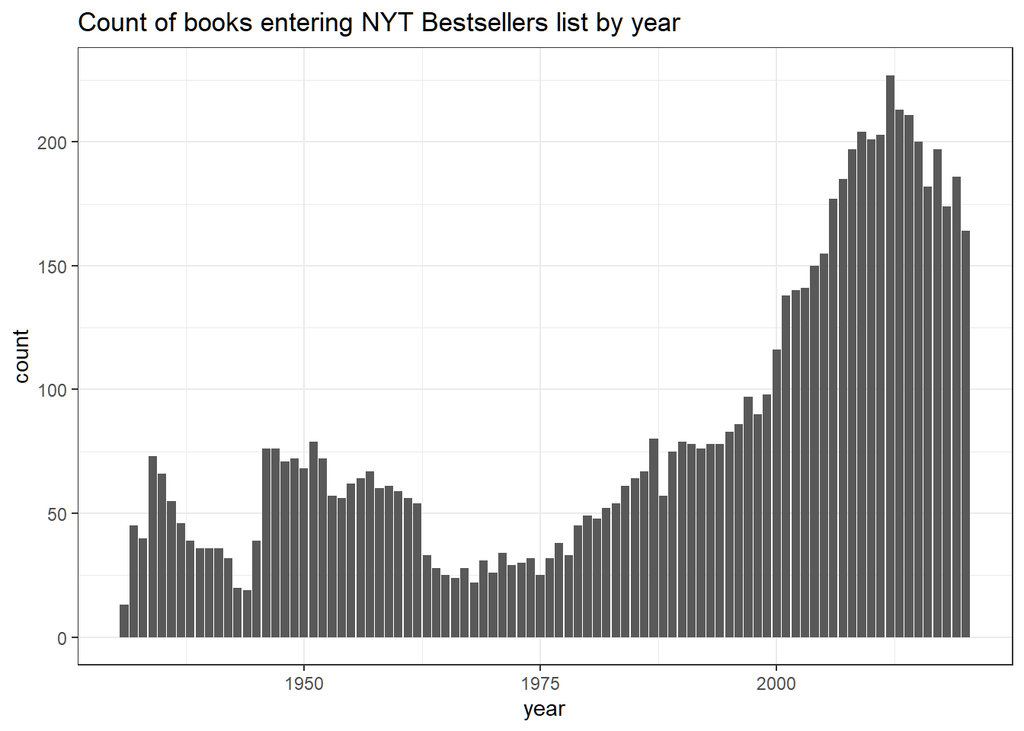

```r
nyt_analysis %>%
  ggplot() +
  geom_bar() +
  aes(year) +
  ggtitle("Count of books entering NYT Bestsellers list by year") +
  theme_bw()
```

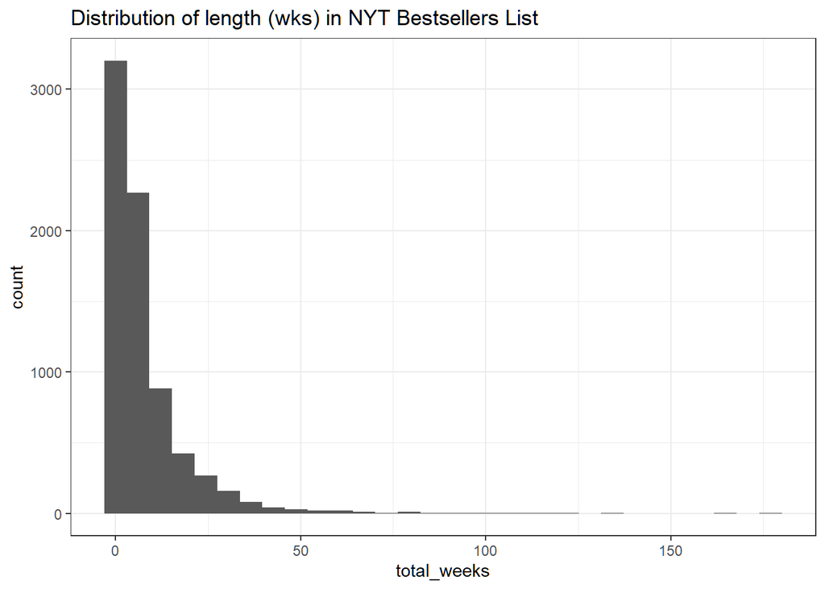

```r
nyt_analysis %>%
  ggplot() +
  geom_histogram() +
  aes(total_weeks) +
  ggtitle("Distribution of length (wks) in NYT Bestsellers List") +
  theme_bw()
```

Which authors show up the most on the NYT Best Sellers list?

```r
nyt_grouped <- nyt_analysis %>%
  group_by(author) %>%
  summarize(n = n(),
            mean_weeks = mean(total_weeks),
            median_weeks = median(total_weeks)) %>%
  arrange(-n)

nyt_grouped
```

```
## # A tibble: 2,206 × 4
##    author                 n mean_weeks median_weeks
##    <chr>              <int>      <dbl>        <dbl>
##  1 Danielle Steel       116       8.25          5.5
##  2 Stuart Woods          63       2.48          2
##  3 Stephen King          54      16.5          15
##  4 Robert B. Parker      47       4.13          4
##  5 John Sandford         44       5.16          5
##  6 David Baldacci        42       9.43         10
##  7 Dean Koontz           40       6.15          5.5
##  8 Mary Higgins Clark    40      10.1           9
##  9 Sandra Brown          40       4.6           4
## 10 Nora Roberts          38       5.05          5
## # … with 2,196 more rows
```

What words most frequently appear in NYT Best Seller titles?

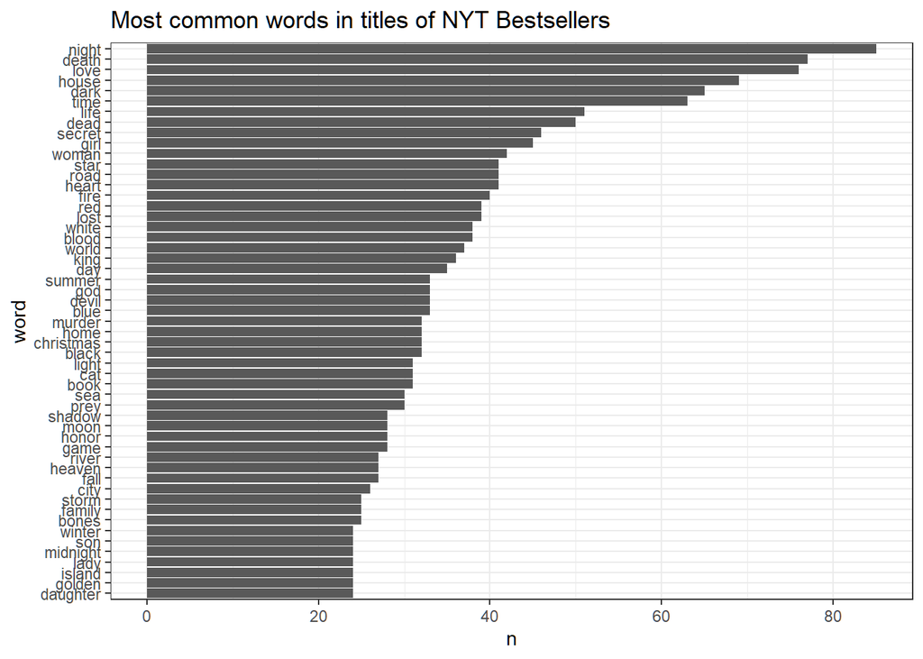

```r
library(tidytext)

title_words <- nyt_analysis %>%
  select(clean_title, author, year,  total_weeks) %>%
  unnest_tokens(word, clean_title) %>%
  anti_join(stop_words, by = "word")

title_words %>%
  group_by(word) %>%
  summarize(n = n()) %>%
  slice_max(order_by = n, n = 50) %>%
  mutate(word = fct_reorder(word, n)) %>%
  ggplot() +
  geom_col() +
  aes(x = n, y = word) +
  ggtitle("Most common words in titles of NYT Bestsellers") +
  theme_bw()
```

# Follow along with Julia Silge Analysis

## Build tidymodel

```r
library(tidymodels)
set.seed(1234)

nyt_split <- nyt_analysis %>%
  transmute(
    author,
    total_weeks = if_else(total_weeks > 4, "long", "short")) %>%
  na.omit() %>%
  initial_split(strat = total_weeks)

nyt_train <- training(nyt_split)
nyt_test <- testing(nyt_split)

set.seed(2345)
nyt_folds <- vfold_cv(nyt_train, strata = total_weeks)
nyt_folds
```

```
## #  10-fold cross-validation using stratification
## # A tibble: 10 × 2
##    splits             id
##    <list>             <chr>
##  1 <split [5012/558]> Fold01
##  2 <split [5013/557]> Fold02
##  3 <split [5013/557]> Fold03
##  4 <split [5013/557]> Fold04
##  5 <split [5013/557]> Fold05
##  6 <split [5013/557]> Fold06
##  7 <split [5013/557]> Fold07
##  8 <split [5013/557]> Fold08
##  9 <split [5013/557]> Fold09
## 10 <split [5014/556]> Fold10
```

```r
library(textrecipes)
svm_spec <- svm_linear(mode = "classification")

nyt_recipe <- recipe(total_weeks ~ author, data = nyt_train) %>%
  step_tokenize_wordpiece(author) %>%
  step_tokenfilter(author, max_tokens = 100) %>%
  step_tf(author) %>%
  step_normalize(all_numeric_predictors())

prep(nyt_recipe) %>% bake(new_data = NULL) %>% skimr::skim()
```

Data summary

| Name | Piped data |
| --- | --- |
| Number of rows | 5570 |
| Number of columns | 101 |
| _______________________ |  |
| Column type frequency: |  |
| factor | 1 |
| numeric | 100 |
| ________________________ |  |
| Group variables | None |

**Variable type: factor**

| skim_variable | n_missing | complete_rate | ordered | n_unique | top_counts |
| --- | --- | --- | --- | --- | --- |
| total_weeks | 0 | 1 | FALSE | 2 | sho: 2849, lon: 2721 |

**Variable type: numeric**

| skim_variable | n_missing | complete_rate | mean | sd | p0 | p25 | p50 | p75 | p100 | hist |
| --- | --- | --- | --- | --- | --- | --- | --- | --- | --- | --- |
| tf_author_’ | 0 | 1 | 0 | 1 | -0.10 | -0.10 | -0.10 | -0.10 | 10.51 | ▇▁▁▁▁ |
| tf_author_##a | 0 | 1 | 0 | 1 | -0.10 | -0.10 | -0.10 | -0.10 | 10.30 | ▇▁▁▁▁ |
| tf_author_##an | 0 | 1 | 0 | 1 | -0.08 | -0.08 | -0.08 | -0.08 | 12.40 | ▇▁▁▁▁ |
| tf_author_##ber | 0 | 1 | 0 | 1 | -0.08 | -0.08 | -0.08 | -0.08 | 12.76 | ▇▁▁▁▁ |
| tf_author_##e | 0 | 1 | 0 | 1 | -0.15 | -0.15 | -0.15 | -0.15 | 6.80 | ▇▁▁▁▁ |
| tf_author_##er | 0 | 1 | 0 | 1 | -0.15 | -0.15 | -0.15 | -0.15 | 6.80 | ▇▁▁▁▁ |
| tf_author_##es | 0 | 1 | 0 | 1 | -0.08 | -0.08 | -0.08 | -0.08 | 12.57 | ▇▁▁▁▁ |
| tf_author_##ford | 0 | 1 | 0 | 1 | -0.08 | -0.08 | -0.08 | -0.08 | 12.57 | ▇▁▁▁▁ |
| tf_author_##in | 0 | 1 | 0 | 1 | -0.08 | -0.08 | -0.08 | -0.08 | 12.23 | ▇▁▁▁▁ |
| tf_author_##l | 0 | 1 | 0 | 1 | -0.08 | -0.08 | -0.08 | -0.08 | 11.91 | ▇▁▁▁▁ |
| tf_author_##m | 0 | 1 | 0 | 1 | -0.09 | -0.09 | -0.09 | -0.09 | 11.61 | ▇▁▁▁▁ |
| tf_author_##man | 0 | 1 | 0 | 1 | -0.12 | -0.12 | -0.12 | -0.12 | 16.58 | ▇▁▁▁▁ |
| tf_author_##n | 0 | 1 | 0 | 1 | -0.12 | -0.12 | -0.12 | -0.12 | 8.56 | ▇▁▁▁▁ |
| tf_author_##ne | 0 | 1 | 0 | 1 | -0.09 | -0.09 | -0.09 | -0.09 | 11.47 | ▇▁▁▁▁ |
| tf_author_##om | 0 | 1 | 0 | 1 | -0.08 | -0.08 | -0.08 | -0.08 | 13.15 | ▇▁▁▁▁ |
| tf_author_##ont | 0 | 1 | 0 | 1 | -0.09 | -0.09 | -0.09 | -0.09 | 11.61 | ▇▁▁▁▁ |
| tf_author_##s | 0 | 1 | 0 | 1 | -0.13 | -0.13 | -0.13 | -0.13 | 7.72 | ▇▁▁▁▁ |
| tf_author_##sen | 0 | 1 | 0 | 1 | -0.08 | -0.08 | -0.08 | -0.08 | 23.89 | ▇▁▁▁▁ |
| tf_author_##ssler | 0 | 1 | 0 | 1 | -0.09 | -0.09 | -0.09 | -0.09 | 17.70 | ▇▁▁▁▁ |
| tf_author_##y | 0 | 1 | 0 | 1 | -0.09 | -0.09 | -0.09 | -0.09 | 11.34 | ▇▁▁▁▁ |
| tf_author_##z | 0 | 1 | 0 | 1 | -0.11 | -0.11 | -0.11 | -0.11 | 9.20 | ▇▁▁▁▁ |
| tf_author_. | 0 | 1 | 0 | 1 | -0.33 | -0.33 | -0.33 | -0.33 | 7.10 | ▇▁▁▁▁ |
| tf_author_a | 0 | 1 | 0 | 1 | -0.12 | -0.12 | -0.12 | -0.12 | 15.82 | ▇▁▁▁▁ |
| tf_author_and | 0 | 1 | 0 | 1 | -0.23 | -0.23 | -0.23 | -0.23 | 8.90 | ▇▁▁▁▁ |
| tf_author_ann | 0 | 1 | 0 | 1 | -0.08 | -0.08 | -0.08 | -0.08 | 12.95 | ▇▁▁▁▁ |
| tf_author_anne | 0 | 1 | 0 | 1 | -0.12 | -0.12 | -0.12 | -0.12 | 8.62 | ▇▁▁▁▁ |
| tf_author_b | 0 | 1 | 0 | 1 | -0.14 | -0.14 | -0.14 | -0.14 | 6.95 | ▇▁▁▁▁ |
| tf_author_barbara | 0 | 1 | 0 | 1 | -0.08 | -0.08 | -0.08 | -0.08 | 12.23 | ▇▁▁▁▁ |
| tf_author_brown | 0 | 1 | 0 | 1 | -0.10 | -0.10 | -0.10 | -0.10 | 17.22 | ▇▁▁▁▁ |
| tf_author_by | 0 | 1 | 0 | 1 | -0.09 | -0.09 | -0.09 | -0.09 | 22.25 | ▇▁▁▁▁ |

[output cut: 70 more lines]

```r
nyt_wf <- workflow(nyt_recipe, svm_spec)

nyt_wf
```

```
## ══ Workflow ════════════════════════════════════════════════════════════════════
## Preprocessor: Recipe
## Model: svm_linear()
##
## ── Preprocessor ────────────────────────────────────────────────────────────────
## 4 Recipe Steps
##
## • step_tokenize_wordpiece()
## • step_tokenfilter()
## • step_tf()
## • step_normalize()
##
## ── Model ───────────────────────────────────────────────────────────────────────
## Linear Support Vector Machine Specification (classification)
##
## Computational engine: LiblineaR
```

## Evaluate models

```r
set.seed(1234)

#doParallel::registerDoParallel()

nyt_metrics <- metric_set(accuracy, sens, spec)
nyt_rs <- fit_resamples(nyt_wf, resamples = nyt_folds, metrics = nyt_metrics)

collect_metrics(nyt_rs)
```

```
## # A tibble: 3 × 6
##   .metric  .estimator  mean     n std_err .config
##   <chr>    <chr>      <dbl> <int>   <dbl> <chr>
## 1 accuracy binary     0.592    10 0.00418 Preprocessor1_Model1
## 2 sens     binary     0.408    10 0.00707 Preprocessor1_Model1
## 3 spec     binary     0.769    10 0.00599 Preprocessor1_Model1
```

```r
final_rs <- last_fit(nyt_wf, nyt_split, metrics = nyt_metrics)
collect_metrics(final_rs)
```

```
## # A tibble: 3 × 4
##   .metric  .estimator .estimate .config
##   <chr>    <chr>          <dbl> <chr>
## 1 accuracy binary         0.589 Preprocessor1_Model1
## 2 sens     binary         0.381 Preprocessor1_Model1
## 3 spec     binary         0.786 Preprocessor1_Model1
```

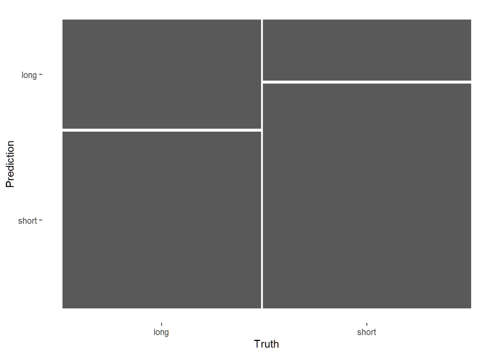

```r
collect_predictions(final_rs) %>%
  conf_mat(total_weeks, .pred_class) %>%
  autoplot()
```

```r
final_fitted <- extract_workflow(final_rs)

#predict(final_fitted, new_data = slice_sample(nyt_test, n = 1))
augment(final_fitted, new_data = slice_sample(nyt_test, n = 1))
```

```
## # A tibble: 1 × 3
##   author          total_weeks .pred_class
##   <chr>           <chr>       <fct>
## 1 Michael Sadleir short       long
```

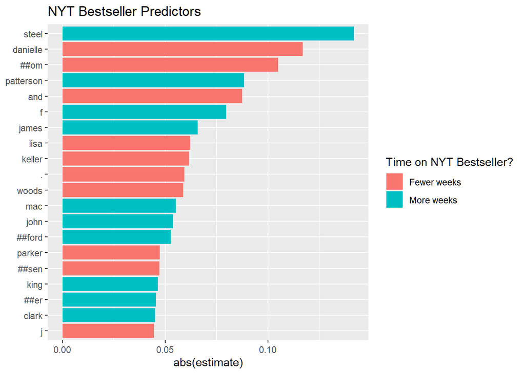

```r
tidy(final_fitted) %>%
  slice_max(abs(estimate), n = 20) %>%
  mutate(term = str_remove_all(term, "tf_author_"),
         term = fct_reorder(term, abs(estimate))
         ) %>%
  ggplot(aes(x = abs(estimate), y = term, fill = estimate > 0 )) +
  geom_col() +
  scale_fill_discrete(labels = c("Fewer weeks", "More weeks"))  +
  labs(y = NULL, fill = "Time on NYT Bestseller?", title = "NYT Bestseller Predictors")
```

# deployable model objects with Vetiver

```r
library(vetiver)
v <- vetiver_model(final_fitted, "nyt_authors")
v
```

```
##
## ── nyt_authors ─ <butchered_workflow> model for deployment
## A LiblineaR classification modeling workflow using 1 feature
```

```r
#library(plumber)

#pr() %>%
#  vetiver_api(v) %>%
#  pr_run()
```

# Save Image

Save your image for sharing. Be sure to use the `#TidyTuesday` hashtag in your post on twitter!

```r
# This will save your most recent plot
ggsave(
  filename = "My TidyTuesday Plot.png",
  device = "png")
```